# II. LASSO REGRESSION AND MODEL SELECTION: WHAT MAKES A GOOD WINE?

# A. Pre-processing

```python
# Importing libraries

import pandas as pd
import numpy as np
import math
import matplotlib
import matplotlib.pyplot as plt
import matplotlib.mlab as mlab

import numpy as np
import random
import math
import matplotlib
import matplotlib.pyplot as plt
import pandas as pd
%matplotlib inline
from pathlib import Path
import time
import sklearn as sk
import sklearn.decomposition
import sklearn.linear_model
import sklearn.model_selection
import sklearn.metrics
import torch as th
```

```python
# Reading data

red_wine=pd.read_csv('winequality-red.csv', sep=';')
```

```python
# Shape of data and seeing the data
display(red_wine[0:5])
red_wine.shape
```

|  | fixed acidity | volatile acidity | citric acid | residual sugar | chlorides | free sulfur dioxide | total sulfur dioxide | density | pH | sulphates | alcohol | quality |
| --- | --- | --- | --- | --- | --- | --- | --- | --- | --- | --- | --- | --- |
| 0 | 7.4 | 0.70 | 0.00 | 1.9 | 0.076 | 11.0 | 34.0 | 0.9978 | 3.51 | 0.56 | 9.4 | 5 |
| 1 | 7.8 | 0.88 | 0.00 | 2.6 | 0.098 | 25.0 | 67.0 | 0.9968 | 3.20 | 0.68 | 9.8 | 5 |
| 2 | 7.8 | 0.76 | 0.04 | 2.3 | 0.092 | 15.0 | 54.0 | 0.9970 | 3.26 | 0.65 | 9.8 | 5 |
| 3 | 11.2 | 0.28 | 0.56 | 1.9 | 0.075 | 17.0 | 60.0 | 0.9980 | 3.16 | 0.58 | 9.8 | 6 |
| 4 | 7.4 | 0.70 | 0.00 | 1.9 | 0.076 | 11.0 | 34.0 | 0.9978 | 3.51 | 0.56 | 9.4 | 5 |

```
(1599, 12)
```

As we can see above, we have 1599 different elements in the set for 12 columns with different features

```python
# Separating data by different columns

f_ac=red_wine['fixed acidity']
v_ac=red_wine['volatile acidity']
c_ac=red_wine['citric acid']
r_sug=red_wine['residual sugar']
chlrd=red_wine['chlorides']
f_sfrdox=red_wine['free sulfur dioxide']
t_sfrdox=red_wine['total sulfur dioxide']
d=red_wine['density']
pH=red_wine['pH']
sulp=red_wine['sulphates']
alc=red_wine['alcohol']
qual=red_wine['quality']
```

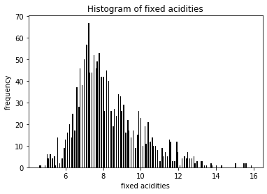

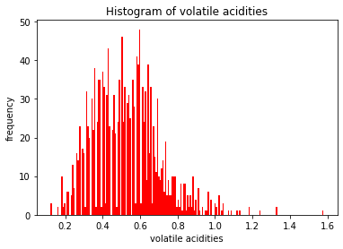

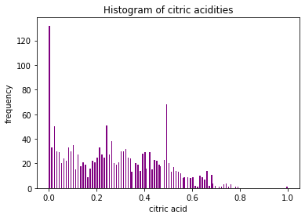

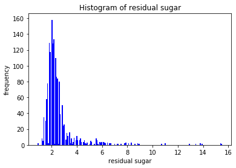

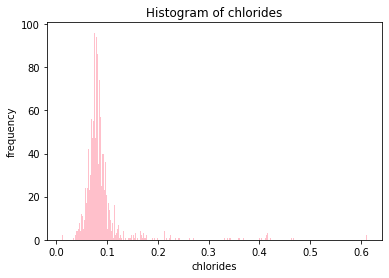

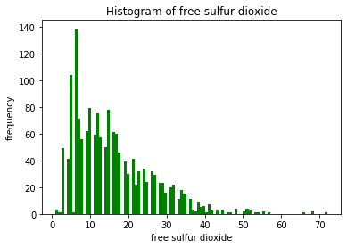

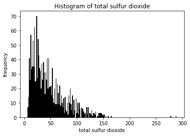

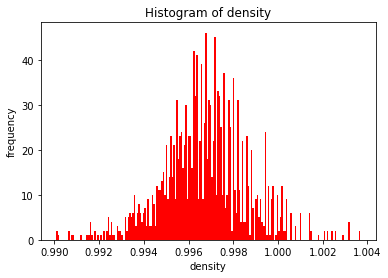

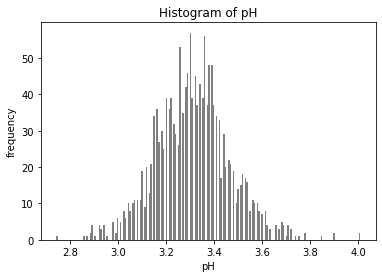

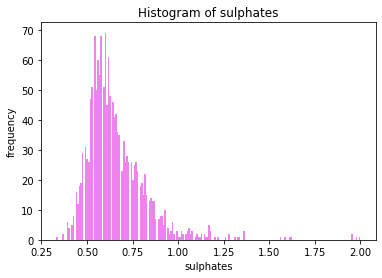

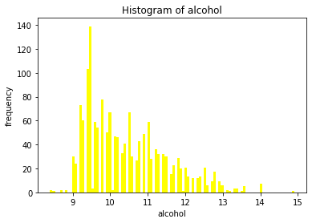

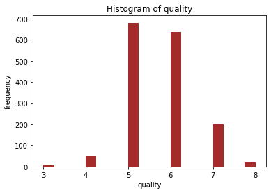

```python
# Histograms

num_bins=200
plt.figure(figsize=(6,4))
n,bins,patches = plt.hist(f_ac,num_bins,facecolor='black',alpha=1)
plt.xlabel('fixed acidities')
plt.ylabel('frequency')
plt.title(r'Histogram of fixed acidities')
plt.show()

num_bins=200
plt.figure(figsize=(6,4))
n1,bins1,patches1 = plt.hist(v_ac,num_bins,facecolor='red',alpha=1)
plt.xlabel('volatile acidities')
plt.ylabel('frequency')
plt.title(r'Histogram of volatile acidities')
plt.show()

num_bins=200
plt.figure(figsize=(6,4))
n2,bins2,patches2 = plt.hist(c_ac,num_bins,facecolor='purple',alpha=1)
plt.xlabel('citric acid')
plt.ylabel('frequency')
plt.title(r'Histogram of citric acidities')
plt.show()

num_bins=200
plt.figure(figsize=(6,4))
n3,bins3,patches3 = plt.hist(r_sug,num_bins,facecolor='blue',alpha=1)
plt.xlabel('residual sugar')
plt.ylabel('frequency')
plt.title(r'Histogram of residual sugar')
plt.show()

num_bins=400
plt.figure(figsize=(6,4))
n4,bins4,patches4 = plt.hist(chlrd,num_bins,facecolor='pink',alpha=1)
plt.xlabel('chlorides')
plt.ylabel('frequency')
plt.title(r'Histogram of chlorides')
plt.show()

num_bins=100
plt.figure(figsize=(6,4))
n5,bins5,patches5 = plt.hist(f_sfrdox,num_bins,facecolor='green',alpha=1)
plt.xlabel('free sulfur dioxide')
plt.ylabel('frequency')
plt.title(r'Histogram of free sulfur dioxide')
plt.show()

num_bins=200
plt.figure(figsize=(6,4))
n5,bins5,patches5 = plt.hist(t_sfrdox,num_bins,facecolor='black',alpha=1)
plt.xlabel('total sulfur dioxide')
plt.ylabel('frequency')
plt.title(r'Histogram of total sulfur dioxide')
plt.show()

num_bins=200
plt.figure(figsize=(6,4))
n5,bins5,patches5 = plt.hist(d,num_bins,facecolor='red',alpha=1)
plt.xlabel('density')
plt.ylabel('frequency')
plt.title(r'Histogram of density')
plt.show()

num_bins=200
plt.figure(figsize=(6,4))
n5,bins5,patches5 = plt.hist(pH,num_bins,facecolor='grey',alpha=1)
plt.xlabel('pH')
plt.ylabel('frequency')
plt.title(r'Histogram of pH')
plt.show()

num_bins=200
plt.figure(figsize=(6,4))
n5,bins5,patches5 = plt.hist(sulp,num_bins,facecolor='violet',alpha=1)
plt.xlabel('sulphates')
plt.ylabel('frequency')
plt.title(r'Histogram of sulphates')
plt.show()

num_bins=100
plt.figure(figsize=(6,4))
n5,bins5,patches5 = plt.hist(alc,num_bins,facecolor='yellow',alpha=1)
plt.xlabel('alcohol')
plt.ylabel('frequency')
plt.title(r'Histogram of alcohol')
plt.show()

num_bins=20
plt.figure(figsize=(6,4))
n5,bins5,patches5 = plt.hist(qual,num_bins,facecolor='brown',alpha=1)
plt.xlabel('quality')
plt.ylabel('frequency')
plt.title(r'Histogram of quality')
plt.show()
```

```python
# Verifying if we do not have any NaN or ? values in between our dataset

print({pd.isna(red_wine).values.any()})
```

```
{False}
```

```python
# Removing outliers

def remove_outliers(red_wine,sd):
    from scipy import stats
    '''
    Creating a function to remove our outliers. These outliers are used defined as a value that is SOME
#standard deviations from the mean value

red_wine is the dataset and sd is HOW MANY standard deviations we'll consider as the limit for the
measurement become an outlier value
'''
    return(red_wine[(np.abs(stats.zscore(red_wine)) < sd).all(axis=1)])
```

Such as asked in the statement of the question, here we tried to remove what we call outliers, points that may disturb our following applications

```python
red_wine = remove_outliers(red_wine,3)
red_wine.shape
```

```
(1451, 12)
```

Here, as expected, we have obtained 1451 points, it means that we drop some points, NOTE THAT we must be careful when using this function, if it is applied again, it will clean some data AGAIN because the standard deviation changed from the last dataset with 1599 points to this new cleaned one with 1451 points, let's reset the data and see the histograms again

```python
# Re-setting data

f_ac=red_wine['fixed acidity']
v_ac=red_wine['volatile acidity']
c_ac=red_wine['citric acid']
r_sug=red_wine['residual sugar']
chlrd=red_wine['chlorides']
f_sfrdox=red_wine['free sulfur dioxide']
t_sfrdox=red_wine['total sulfur dioxide']
d=red_wine['density']
pH=red_wine['pH']
sulp=red_wine['sulphates']
alc=red_wine['alcohol']
qual=red_wine['quality']
```

The histograms after cleaning the data are also shown below, as we can see, data data are more than 3 standard deviations away from the center were cleaned and considered as an outlier

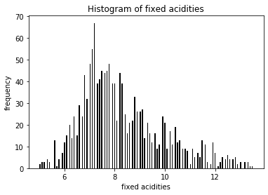

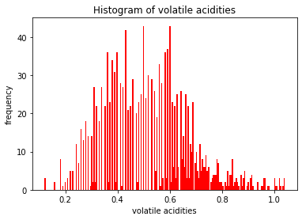

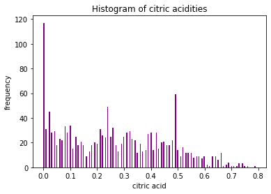

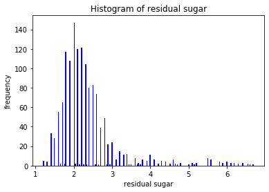

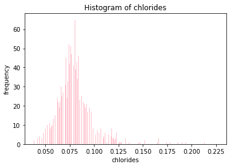

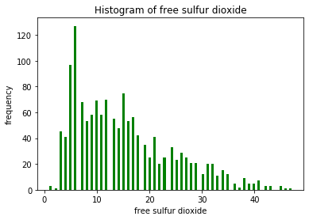

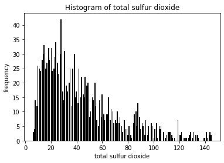

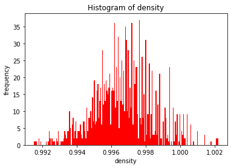

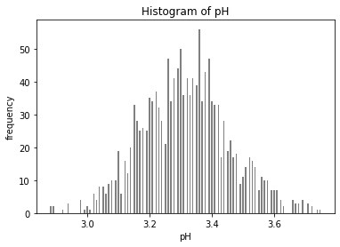

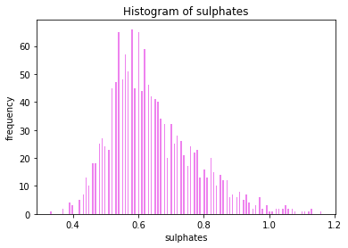

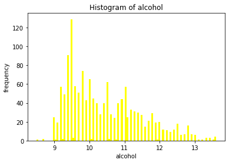

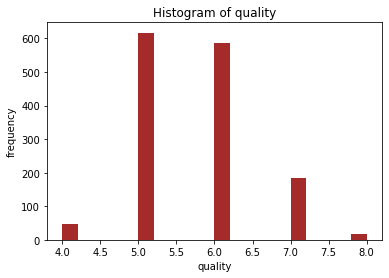

```python
# Histograms

num_bins=200
plt.figure(figsize=(6,4))
n,bins,patches = plt.hist(f_ac,num_bins,facecolor='black',alpha=1)
plt.xlabel('fixed acidities')
plt.ylabel('frequency')
plt.title(r'Histogram of fixed acidities')
plt.show()

num_bins=200
plt.figure(figsize=(6,4))
n1,bins1,patches1 = plt.hist(v_ac,num_bins,facecolor='red',alpha=1)
plt.xlabel('volatile acidities')
plt.ylabel('frequency')
plt.title(r'Histogram of volatile acidities')
plt.show()

num_bins=200
plt.figure(figsize=(6,4))
n2,bins2,patches2 = plt.hist(c_ac,num_bins,facecolor='purple',alpha=1)
plt.xlabel('citric acid')
plt.ylabel('frequency')
plt.title(r'Histogram of citric acidities')
plt.show()

num_bins=200
plt.figure(figsize=(6,4))
n3,bins3,patches3 = plt.hist(r_sug,num_bins,facecolor='blue',alpha=1)
plt.xlabel('residual sugar')
plt.ylabel('frequency')
plt.title(r'Histogram of residual sugar')
plt.show()

num_bins=400
plt.figure(figsize=(6,4))
n4,bins4,patches4 = plt.hist(chlrd,num_bins,facecolor='pink',alpha=1)
plt.xlabel('chlorides')
plt.ylabel('frequency')
plt.title(r'Histogram of chlorides')
plt.show()

num_bins=100
plt.figure(figsize=(6,4))
n5,bins5,patches5 = plt.hist(f_sfrdox,num_bins,facecolor='green',alpha=1)
plt.xlabel('free sulfur dioxide')
plt.ylabel('frequency')
plt.title(r'Histogram of free sulfur dioxide')
plt.show()

num_bins=200
plt.figure(figsize=(6,4))
n5,bins5,patches5 = plt.hist(t_sfrdox,num_bins,facecolor='black',alpha=1)
plt.xlabel('total sulfur dioxide')
plt.ylabel('frequency')
plt.title(r'Histogram of total sulfur dioxide')
plt.show()

num_bins=200
plt.figure(figsize=(6,4))
n5,bins5,patches5 = plt.hist(d,num_bins,facecolor='red',alpha=1)
plt.xlabel('density')
plt.ylabel('frequency')
plt.title(r'Histogram of density')
plt.show()

num_bins=200
plt.figure(figsize=(6,4))
n5,bins5,patches5 = plt.hist(pH,num_bins,facecolor='grey',alpha=1)
plt.xlabel('pH')
plt.ylabel('frequency')
plt.title(r'Histogram of pH')
plt.show()

num_bins=200
plt.figure(figsize=(6,4))
n5,bins5,patches5 = plt.hist(sulp,num_bins,facecolor='violet',alpha=1)
plt.xlabel('sulphates')
plt.ylabel('frequency')
plt.title(r'Histogram of sulphates')
plt.show()

num_bins=100
plt.figure(figsize=(6,4))
n5,bins5,patches5 = plt.hist(alc,num_bins,facecolor='yellow',alpha=1)
plt.xlabel('alcohol')
plt.ylabel('frequency')
plt.title(r'Histogram of alcohol')
plt.show()

num_bins=20
plt.figure(figsize=(6,4))
n5,bins5,patches5 = plt.hist(qual,num_bins,facecolor='brown',alpha=1)
plt.xlabel('quality')
plt.ylabel('frequency')
plt.title(r'Histogram of quality')
plt.show()
```

```python
# Visualizing the QUALITY column as numpy and as a panda dataframe

qual=qual.to_numpy()
display(qual)
print('###########################################33')
qual=pd.DataFrame(qual)
display(qual[0])
```

```
array([5, 5, 5, ..., 6, 5, 6], dtype=int64)
```

```
###########################################33
```

```
0       5
1       5
2       5
3       6
4       5
       ..
1446    5
1447    6
1448    6
1449    5
1450    6
Name: 0, Length: 1451, dtype: int64
```

# B. Principal component analysis (PCA)

Now we are going to perform a principal component analysis on our data considering all the features together (p = 12) and with the normalized data with zero mean and unit variance. This normalization means that there are no distortions in our analyzes due to the difference in magnitude orders of the features and their different units of measurement.

```python
#Importing to do the normalization
from sklearn.preprocessing import StandardScaler
```

```python
features= ['fixed acidity','volatile acidity','citric acid','residual sugar','chlorides','free sulfur dioxide','total sulfur dioxide','density','pH','sulphates','alcohol']
red_wine_features = red_wine.loc[:, features].values


red_wineN=StandardScaler().fit_transform(red_wine) # Normalizing each feature to mean = 0 and variance = 1
red_wineN=pd.DataFrame(red_wineN)
display(red_wine[0:5])
red_wine.mean()
```

|  | fixed acidity | volatile acidity | citric acid | residual sugar | chlorides | free sulfur dioxide | total sulfur dioxide | density | pH | sulphates | alcohol | quality |
| --- | --- | --- | --- | --- | --- | --- | --- | --- | --- | --- | --- | --- |
| 0 | 7.4 | 0.70 | 0.00 | 1.9 | 0.076 | 11.0 | 34.0 | 0.9978 | 3.51 | 0.56 | 9.4 | 5 |
| 1 | 7.8 | 0.88 | 0.00 | 2.6 | 0.098 | 25.0 | 67.0 | 0.9968 | 3.20 | 0.68 | 9.8 | 5 |
| 2 | 7.8 | 0.76 | 0.04 | 2.3 | 0.092 | 15.0 | 54.0 | 0.9970 | 3.26 | 0.65 | 9.8 | 5 |
| 3 | 11.2 | 0.28 | 0.56 | 1.9 | 0.075 | 17.0 | 60.0 | 0.9980 | 3.16 | 0.58 | 9.8 | 6 |
| 4 | 7.4 | 0.70 | 0.00 | 1.9 | 0.076 | 11.0 | 34.0 | 0.9978 | 3.51 | 0.56 | 9.4 | 5 |

```
fixed acidity            8.310062
volatile acidity         0.522950
citric acid              0.265382
residual sugar           2.387285
chlorides                0.081425
free sulfur dioxide     15.104755
total sulfur dioxide    43.735355
density                  0.996710
pH                       3.315934
sulphates                0.642584
alcohol                 10.421089
quality                  5.659545
dtype: float64
```

```python
display(red_wineN[0:5])
display(red_wineN.mean())
display(red_wineN.std())
```

|  | 0 | 1 | 2 | 3 | 4 | 5 | 6 | 7 | 8 | 9 | 10 | 11 |
| --- | --- | --- | --- | --- | --- | --- | --- | --- | --- | --- | --- | --- |
| 0 | -0.552930 | 1.050914 | -1.390400 | -0.565439 | -0.258851 | -0.441060 | -0.330784 | 0.635485 | 1.375896 | -0.636458 | -0.999856 | -0.844125 |
| 1 | -0.309900 | 2.119336 | -1.390400 | 0.246832 | 0.790825 | 1.063255 | 0.790477 | 0.052390 | -0.821951 | 0.288353 | -0.608174 | -0.844125 |
| 2 | -0.309900 | 1.407054 | -1.180831 | -0.101284 | 0.504550 | -0.011256 | 0.348768 | 0.169009 | -0.396561 | 0.057150 | -0.608174 | -0.844125 |
| 3 | 1.755851 | -1.442071 | 1.543569 | -0.565439 | -0.306564 | 0.203646 | 0.552634 | 0.752103 | -1.105544 | -0.482323 | -0.608174 | 0.435734 |
| 4 | -0.552930 | 1.050914 | -1.390400 | -0.565439 | -0.258851 | -0.441060 | -0.330784 | 0.635485 | 1.375896 | -0.636458 | -0.999856 | -0.844125 |

```
0     1.903677e-16
1    -3.247268e-16
2     3.798172e-16
3    -2.555579e-16
4     6.258873e-17
5    -3.516981e-16
6    -2.139293e-16
7     2.754730e-14
8    -5.232815e-16
9    -2.678002e-18
10   -4.307757e-17
11   -7.944484e-16
dtype: float64
```

```
0     1.000345
1     1.000345
2     1.000345
3     1.000345
4     1.000345
5     1.000345
6     1.000345
7     1.000345
8     1.000345
9     1.000345
10    1.000345
11    1.000345
dtype: float64
```

As we can see above, the data has been normalized correctly. Now, we can perform a PCA analysis. There are several ways to do this analysis - we will use sklearn's libraries.

```python
from sklearn.decomposition import PCA

pca=PCA()
pca.fit(red_wineN)
```

```
PCA(copy=True, iterated_power='auto', n_components=None, random_state=None,
    svd_solver='auto', tol=0.0, whiten=False)
```

Now, let's analyze the data projection in the first two eigenvectors, indicating the quality of each point

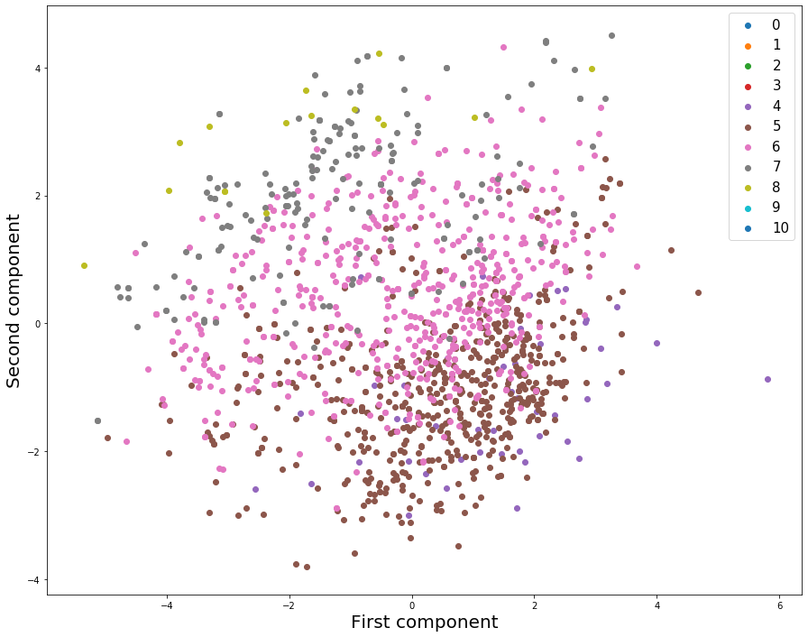

```python
listq=[0,1,2,3,4,5,6,7,8,9,10]  #quality values
P=pca.transform(red_wineN)[:,0:2] # top two components

plt.figure(figsize=(15,12))
for i in range(11):
    plt.scatter(P[(qual[0]==i),0],P[(qual[0]==i),1])
plt.legend(listq,fontsize=15)
plt.xlabel("First component",fontsize=20)
plt.ylabel("Second component",fontsize=20)
```

The figure above shows the data projection in the two "best eigenvectors". We know that they are the vectors that hold most of the information and are able to better separate the data - we will be able to find out how good they are by analyzing each one's eingenvalues (inertia distribution). To complete, it is possible to verify some agglomerations of data of the same quality, but it is still difficult to distinguish them clearly.

Let's take a look at the eigenvalues and the weight that each one has in percentage

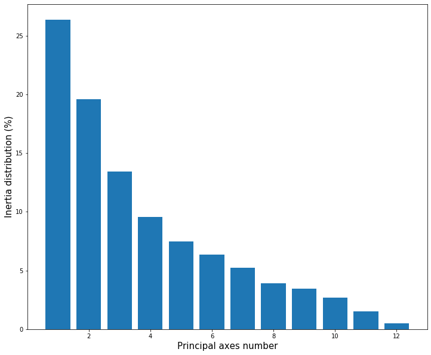

```python
plt.figure(figsize=(12,10))
xxx=np.linspace(1,12,12)
plt.bar(xxx,pca.explained_variance_ratio_*100)
plt.xlabel('Principal axes number',fontsize=15)
plt.ylabel('Inertia distribution (%)',fontsize=15)
```

As we can see above, the first eigenvalue has a weight of 26% and the second 19% - adding both, we have a percentage of 45%. We can interpret it as the percentage of information that is retained when making data projections on eigenvectors. Thus, as we do not have even half the information, this explains our difficulty in being able to visualize and separate the data in the first graph shown.

Our next step is to visualize the first two eigenvectors (in two dimensions) and try to see if there is a clear correlation between quality and some other feature:

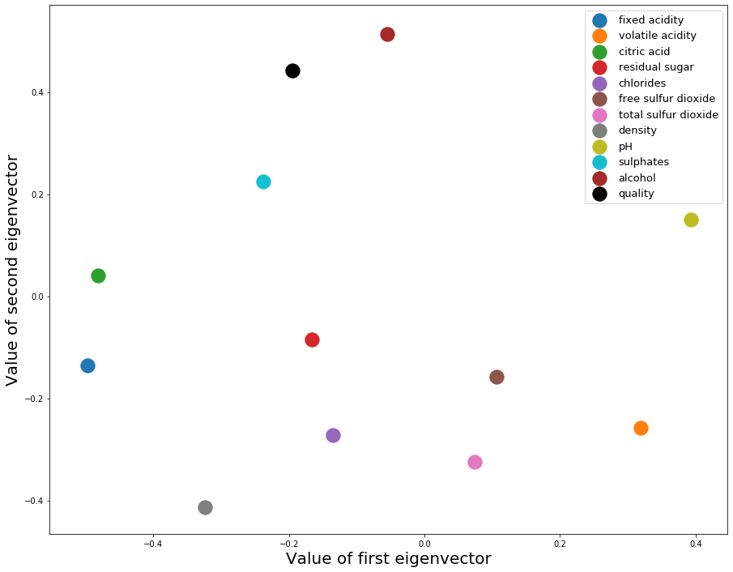

```python
features= ['fixed acidity','volatile acidity','citric acid','residual sugar','chlorides','free sulfur dioxide','total sulfur dioxide','density','pH','sulphates','alcohol', 'quality']

plt.figure(figsize=(15,12))
for i in range(10):
    plt.scatter(pca.components_[0,i],pca.components_[1,i],s=300)
plt.scatter(pca.components_[0,10],pca.components_[1,10],s=300,c='brown')
plt.scatter(pca.components_[0,11],pca.components_[1,11],s=300,c='black')
plt.legend(features,prop={"size":13})
plt.xlabel("Value of first eigenvector",fontsize=20)
plt.ylabel("Value of second eigenvector",fontsize=20)
```

We know that in this case the points that are close express a positive correlation (similar behavior) and points that are very distant have the opposite correlation. In this way, we can infer that the points close to the quality point have a high correlation with it and the points far away have an anti-correlation. Visually analyzing, we are able to conclude that the parameters alcohol and sulfates have a high correlation with quality whereas the parameters density and volatile acidity have high anti-correlation. However, as we saw that each eigenvector retains little information, we cannot infer that these few parameters perfectly describe the reasons for the quality of the wines.

# C. Multivariate linear regression

Our objective is to apply Multivariate linear regression and the ideia is to fit the data with an hyperplane, to do so, we considered a linear model such as $$\hat{y} = \sum \beta_{j}x_{j} + \alpha $$

However, we did not want to have a bias element, and by setting the mean value as 0 we are able to get $$\hat{y} = \sum \beta_{j}x_{j} $$

When we are programming and we work with a high amount of data, it may seems very interesting to use the matrix notation. All the data can be represented by:

- N × p matrix $X_{ij}$ of $p=11$ features that we consider as inputs.
- N-dimensional vector $Y_{i}$ representing the quality

We can write the loss function as and use the matrix notation:

$$\mathcal{L} = \frac{1}{N} \sum_{i}^N ( Y_{i} - \sum_{j}^p \beta_{j}X_{ij})^{2} = \frac{1}{N} (Y- X\beta)^{T}(Y- X\beta) $$

If we derivates the loss function and equalizes it to zero we will be able to get:

$$\hat{\beta} = (X^{T}X)^{-1}X^{T}Y $$

and the $R^{2}$ coefficient for the case with zero mean and $\alpha=0$ is:

$$ R^{2} = 1 - \frac{\overline{(y - \hat{\beta}x)^{2}}}{\overline{y^{2}}} $$

$R^{2} \in [0, 1]$ is often called by coefficient of determination and it can be considered as a measure of the goodness-of-fit, the closest to one, the better our fit will be.

We started by setting the mean of the features to zero as asked

```python
features= ['fixed acidity','volatile acidity','citric acid','residual sugar','chlorides','free sulfur dioxide','total sulfur dioxide','density','pH','sulphates','alcohol']
red_wine_features=pd.DataFrame(red_wine_features)
red_wine_features.columns=features
for k in features:
    red_wine_features[k]=red_wine_features[k]-red_wine_features[k].mean() # setting mean to 0
```

```python
display(red_wine_features.mean()) #checking that the mean is indeed 0
```

```
fixed acidity          -2.448030e-14
volatile acidity       -4.043400e-16
citric acid             1.078183e-15
residual sugar         -2.985589e-16
chlorides               4.499712e-16
free sulfur dioxide     8.919735e-15
total sulfur dioxide   -9.632727e-14
density                 4.916811e-16
pH                     -4.988735e-16
sulphates              -8.783081e-16
alcohol                 3.124478e-14
dtype: float64
```

Here, we want to take the numpy arrays so that:

- We have our X matrix in the Linear Regression Model, something in N x p form, with p << N --> red_wine_arr
- We have our Y vector of the Linear Regression Model, a vector with N points --> qual_arr

```python
# Taking the numpy array of the features, the mean is already zero for them

red_wine_arr=red_wine_features.values

# Setting mean 0 and taking the numpy array of the quality

qual_arr=(qual - qual.mean()).values
```

Here, we tried to create a function that performs linear regression from scratch as explained in the beginning of this chapter by implementing $\beta$ and $R^{2}$, the idea was to compare this created function with the function from the library sklearn. Note that our function is not generalised for the case where we have a BIAS, it means that it makes NO SENSE apply our created function to a biased dataset with mean different of zero

```python
# Function that calculates the Linear regression model when we do not have a linear coefficient

def LinearReg(X,Y):
    from numpy.linalg import inv
    '''We have:
       N = Number of points
       p = Number of features
       X = Matrix of measurement of features (size N x p)
       Y = Matrix of answer/target that we want to achieve for the previous features (size N x 1)
       OBS: In this model, we cannot have a linear coefficient, it means that, we MUST normalize X and Y sets to mean 0
       '''
    X_star = inv((X.T)@X)@(X.T)
    Beta = X_star@Y
    R_squared = (1 - (((Y - X@Beta)**2).mean(0))/(Y**2).mean(0)).squeeze()
    return Beta, R_squared
```

We tried to realize a sanity check, with a simple array, using OUR FUNCTION and SKLEARN. OBS: Again, we must use a dataset that has mean 0, this is very important, our model does not consider a bias

```python
# Let's test our function and compare with something that is already implemented in Python sklearn
# Simple multivariable linear regression in sklearn

from sklearn.linear_model import LinearRegression

X = np.array([[-.5, -1], [-.5, 0], [.5, 0], [.5, 1]])     # 4 x 2

y = np.array([[6], [8], [9], [11]]) - 8.5                # 4 X 1
reg = LinearRegression(fit_intercept=False).fit(X, y)

print('For the SKLEARN regression:')
print('The coefficients for the regression are:')
print(reg.coef_.T)
print('The R² value is:')
print(reg.score(X, y))
print('#####################################################')

# Simple multivariable linear regression with our function

Beta, R_squared= LinearReg(X,y)
print('For OUR FUNCTION:')
print('The coefficients for the regression are:')
print(Beta)
print('The R² value is:')
print(R_squared)
```

```
For the SKLEARN regression:
The coefficients for the regression are:
[[1.]
 [2.]]
The R² value is:
1.0
#####################################################
For OUR FUNCTION:
The coefficients for the regression are:
[[1.]
 [2.]]
The R² value is:
1.0
```

As we can see the function that we created passed in the sanity check, let's apply both the sklearn and our function for the wine dataset that is our real interest

$\textbf{Applying the multivariable linear regression for the case when both the MEAN=0}$

```python
# Comparing both models to our WINE analysis with Mean = 0

reg_VRAI=LinearRegression(fit_intercept=False).fit(red_wine_arr,qual_arr)
Beta, R_squared = LinearReg(red_wine_arr,qual_arr)

print('Betas with sklearn: ','\n',reg_VRAI.coef_.T,'\n','\n','R² with sklearn: ',reg_VRAI.score(red_wine_arr,qual_arr))
print()
print('Betas with our model: ','\n',Beta,'\n','\n','R² with our model: ',R_squared)
```

```
Betas with sklearn:
 [[ 2.05433088e-02]
 [-7.78967952e-01]
 [-2.12211159e-01]
 [ 1.17088726e-02]
 [-9.28847321e-01]
 [ 3.85286883e-03]
 [-3.56799549e-03]
 [-2.04128490e+01]
 [-5.58364065e-01]
 [ 1.43916109e+00]
 [ 2.84194836e-01]]

 R² with sklearn:  0.3796511829563952

Betas with our model:
 [[ 2.05433088e-02]
 [-7.78967952e-01]
 [-2.12211159e-01]
 [ 1.17088726e-02]
 [-9.28847321e-01]
 [ 3.85286883e-03]
 [-3.56799549e-03]
 [-2.04128490e+01]
 [-5.58364065e-01]
 [ 1.43916109e+00]
 [ 2.84194836e-01]]

 R² with our model:  0.3796511829563951
```

$\textbf{Applying the same multivariable linear regression for the case when both the MEAN=0 and VARIANCE = 1}$

```python
# Applying the same multivariable linear regression for the case when both the MEAN=0 and VARIANCE = 1 and comparing with our function

red_wineN=StandardScaler().fit_transform(red_wine_features) # Normalizing each feature to mean = 0 and variance = 1
red_wineN_pd=pd.DataFrame(red_wineN)
red_wineN_pd.columns=features
qualN=StandardScaler().fit_transform(qual) # Normalizing the quality to mean = 0 and variance = 1


reg_skt=LinearRegression(fit_intercept=False).fit(red_wineN,qualN)
Beta1, R_squared1 = LinearReg(red_wineN,qualN)

print('Betas with sklearn: ','\n',reg_skt.coef_.T,'\n','\n','R² with sklearn: ',reg_skt.score(red_wineN,qualN))
print()
print('Betas with our model: ','\n',Beta1,'\n','\n','R² with our model: ',R_squared1)
```

```
Betas with sklearn:
 [[ 0.04327463]
 [-0.16796212]
 [-0.05183975]
 [ 0.01291439]
 [-0.02491573]
 [ 0.04589184]
 [-0.1343982 ]
 [-0.04480504]
 [-0.10079611]
 [ 0.23900095]
 [ 0.37145348]]

 R² with sklearn:  0.37965118295639505

Betas with our model:
 [[ 0.04327463]
 [-0.16796212]
 [-0.05183975]
 [ 0.01291439]
 [-0.02491573]
 [ 0.04589184]
 [-0.1343982 ]
 [-0.04480504]
 [-0.10079611]
 [ 0.23900095]
 [ 0.37145348]]

 R² with our model:  0.3796511829563951
```

Let's analyse these results:

- We must comment on the $R²$ (score) value. For regression models, as R² approaches the value of 1 we can say that our model describes better the data. In our case, we have a $R²=0.38$ as score, what represents a low value and it also shows that this approach may not be the the most adequate for our wine dataset. Basically, the model explains around 38% of the variance for the Y feature, in our case, the quality that we want to predict.
- Also, the Y set is composed by discrete (and NOT CONTINUOUS) values, it means that we have discrete values for the quality and this affects the model.
- Besides this, the dataset has A LOT of its values concentred between 5, 6 and 7 of quality values, which represents a bad distribution for quality values inside of the total possibilities (from 0 to 10).

Let's observe graphically the differences between the coefficients of the two processes:

- Multilinear regression for the dataset with mean=0
- Multilinear regression for the dataset with mean=0 and variance=1

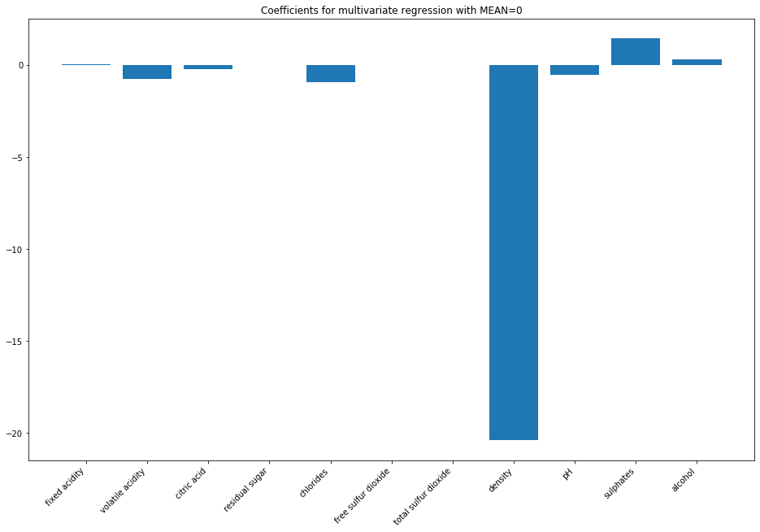

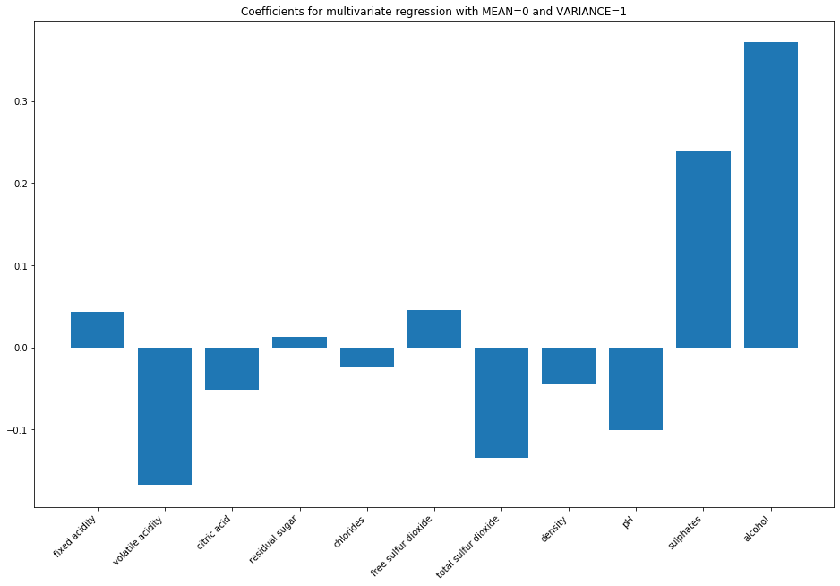

```python
plt.figure(figsize=(16,10))
plt.bar(features,Beta[:,0])
plt.xticks(rotation=45, ha="right")
plt.title(r'Coefficients for multivariate regression with MEAN=0')
plt.show()


plt.figure(figsize=(16,10))
plt.bar(features,Beta1[:,0])
plt.xticks(rotation=45, ha="right")
plt.title(r'Coefficients for multivariate regression with MEAN=0 and VARIANCE=1')
plt.show()
```

From the coefficients obtained in the last graphics:

- The first graphic is not the most adequate to compare features since $\textbf{each feature has different variances}$, we would be comparing different orders of magnitudes.
- Through the second graphic, $\textbf{where each feature has the same unitary variance}$, we can compare features with each other and it is possible to see which features have more influence on the quality of the wine.
  - Alcohol and sulphates are the most important factors and influences positively in the quality
  - Volatile acidity, total sulfur dioxide and pH also present significant influence, but with a negatively influence in the quality

# D. Lasso regression and model selection

Here we want to select a few features as good predictors of quality. For this, we will implement the lasso regression. Lasso performs a so called L1 regularization (a process of introducing additional information in order to prevent overfitting), i.e. adds penalty equivalent to absolute value of the magnitude of coefficients. In the lasso regression, the minimization objective is:

$$ min_{\beta}[ \frac{1}{N}(\sum_{i=1}^N y_{i} - \sum_{j}^p \beta_{j=1} x_{ij})^2 + \lambda \sum_{j=1}^p |\beta_{j}|] $$

for different values of $ \lambda $. First, let's indicate some useful initial values. We will divide the initial dataset in two subsets: a training set of size N = 500 and a test set of size 951 containing the rest of the samples.

```python
wine = red_wine
n,p=np.shape(wine)
n_train, n_test, feature = 500, 951, 11
perc = n_test/(n_train+n_test)
```

Let's now normalize the data with sklearn library

```python
STDscaler = sklearn.preprocessing.StandardScaler(with_std = True).fit(wine)
wineN = STDscaler.transform(wine) # data is scaled to null mean and unit variance
```

To select which data will be tested and which will be used for training, we will shuffle the order of the data and then take the first 500 as a training and the rest as a test.

```python
neworder = random.sample(range(n),n)
train = wineN[neworder[0:n_train],:]
test = wineN[neworder[n_train:n_train+n_test],:]
```

Now let's select the values of lambdas for testing (distributed in a logarithmic scale in the range 10-^3 - 1). Then we will use again the sklearn library to perform the lasso regression:

```python
sizeL=100
lambdas = np.logspace(-3,0,num=sizeL) # lambdas to test

#Computing regularization path using the lasso
lambdas , coefs , _ = sklearn.linear_model.lasso_path(train[:,0:feature],train[:,-1],alphas=lambdas)
```

We plot each coefficient as a function of lambda:

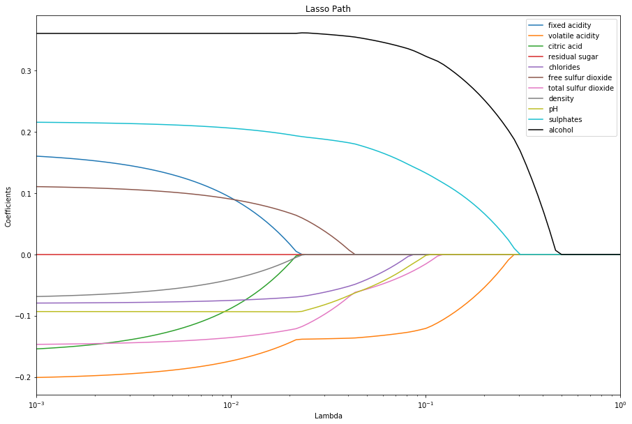

```python
plt.figure(figsize=(15,10))
for i in range(feature-1):
    plt.plot(lambdas,coefs[i,:])
plt.plot(lambdas,coefs[10,:],'black')
plt.legend(red_wine.columns[0:11])
plt.ylabel('Coefficients')
plt.xlabel('Lambda')
plt.title('Lasso Path')
plt.axis('tight')
plt.xlim((1e-3,1))
plt.xscale("log")
```

To find the best lambda that minimizes our problem, we will implement K-fold cross-validation of lasso regression (model with iterative fitting along a regularization path that select the best model by cross-validation.). To find the best lambda, we make an average of all mse (10) and look for the lambda that gives the lowest value of the mean squared error.We use scikit learn again:

```python
K=10

cv_lasso = sklearn.linear_model.LassoCV(cv=K,alphas=lambdas).fit(train[:,0:feature],train[:,-1])
mean_mse = np.mean(cv_lasso.mse_path_,axis=1) # mean mse of the K=10 validation sets
lambda_min = lambdas[np.argmin(mean_mse)] # lambda that minimises the mean square error on the validation sets
print('Lambda min:',lambda_min)
```

```
Lambda min: 0.0037649358067924675
```

So, let's plot the graphs and indicate the minimum lambda

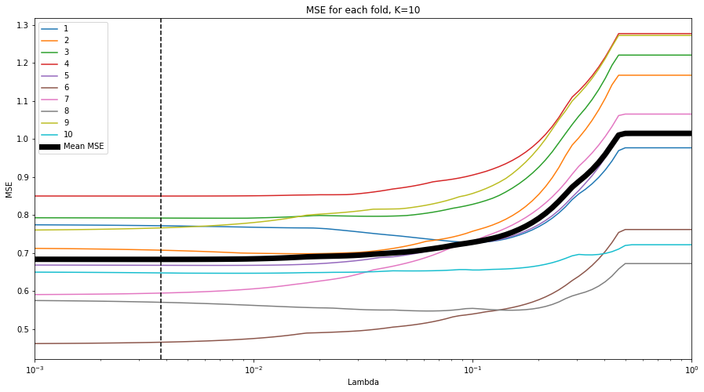

```python
plt.figure(figsize=(15,8))
for i in range(K):
    plt.plot(lambdas,cv_lasso.mse_path_[:,i])
plt.plot(lambdas,mean_mse,'black',linewidth=7.0)
plt.legend([1,2,3,4,5,6,7,8,9,10,'Mean MSE'])
plt.ylabel('MSE')
plt.xlabel('Lambda')
plt.title('MSE for each fold, K=10')
plt.axis('tight')
plt.axvline(x=lambda_min,color='k',linestyle='--')
plt.xlim((1e-3,1))
plt.xscale("log")
```

The lambda minimum reinforces the fact that the most important characteristics for the quality of the wine are alcohol, sulphates, volatile acidity and total sulfur diodixe (as explained before).

Finally, we will perform the lasso regression for several different lambdas in the training data and then measure the score of the training and test data. We will plot here the result:

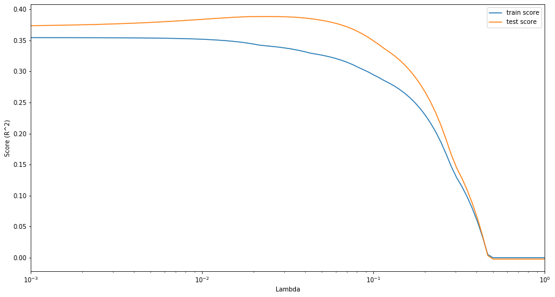

```python
train_score,test_score = np.zeros([1 ,sizeL]),np.zeros([1 ,sizeL])

for i in range (sizeL):
    reg = sklearn.linear_model.Lasso(alpha=lambdas[i])
    reg.fit(train[:,0:feature],train[:,-1])
    train_score[0,i] = reg.score(train[:,0:feature],train[:,-1])
    test_score[0,i] = reg.score(test[:,0:feature],test[:,-1])

plt.figure(figsize=(15,8))
plt.plot(lambdas,train_score[0])
plt.plot(lambdas, test_score[0])
plt.legend(['train score','test score'])
plt.ylabel('Score (R^2)')
plt.xlabel('Lambda')
plt.axis('tight')
plt.xlim((1e-3,1))
plt.xscale("log")
```

Answering the last question: to estimate quality using just a few physicochemical properties, alcohol, sulphates, volatile acidity and total sulfur diodixe should be used because the absolute value of their coefficients are the largest in the minimum lambda.

# E. Classification task

Before even describing the model that we'll use, let's work with the data and try to separate our set into:

- The training set
- The testing set

```python
# Reading data

RW=pd.read_csv('winequality-red.csv',sep=';')
WW=pd.read_csv('winequality-white.csv',sep=';')
display(RW.head())
display(WW.head())
```

|  | fixed acidity | volatile acidity | citric acid | residual sugar | chlorides | free sulfur dioxide | total sulfur dioxide | density | pH | sulphates | alcohol | quality |
| --- | --- | --- | --- | --- | --- | --- | --- | --- | --- | --- | --- | --- |
| 0 | 7.4 | 0.70 | 0.00 | 1.9 | 0.076 | 11.0 | 34.0 | 0.9978 | 3.51 | 0.56 | 9.4 | 5 |
| 1 | 7.8 | 0.88 | 0.00 | 2.6 | 0.098 | 25.0 | 67.0 | 0.9968 | 3.20 | 0.68 | 9.8 | 5 |
| 2 | 7.8 | 0.76 | 0.04 | 2.3 | 0.092 | 15.0 | 54.0 | 0.9970 | 3.26 | 0.65 | 9.8 | 5 |
| 3 | 11.2 | 0.28 | 0.56 | 1.9 | 0.075 | 17.0 | 60.0 | 0.9980 | 3.16 | 0.58 | 9.8 | 6 |
| 4 | 7.4 | 0.70 | 0.00 | 1.9 | 0.076 | 11.0 | 34.0 | 0.9978 | 3.51 | 0.56 | 9.4 | 5 |

|  | fixed acidity | volatile acidity | citric acid | residual sugar | chlorides | free sulfur dioxide | total sulfur dioxide | density | pH | sulphates | alcohol | quality |
| --- | --- | --- | --- | --- | --- | --- | --- | --- | --- | --- | --- | --- |
| 0 | 7.0 | 0.27 | 0.36 | 20.7 | 0.045 | 45.0 | 170.0 | 1.0010 | 3.00 | 0.45 | 8.8 | 6 |
| 1 | 6.3 | 0.30 | 0.34 | 1.6 | 0.049 | 14.0 | 132.0 | 0.9940 | 3.30 | 0.49 | 9.5 | 6 |
| 2 | 8.1 | 0.28 | 0.40 | 6.9 | 0.050 | 30.0 | 97.0 | 0.9951 | 3.26 | 0.44 | 10.1 | 6 |
| 3 | 7.2 | 0.23 | 0.32 | 8.5 | 0.058 | 47.0 | 186.0 | 0.9956 | 3.19 | 0.40 | 9.9 | 6 |
| 4 | 7.2 | 0.23 | 0.32 | 8.5 | 0.058 | 47.0 | 186.0 | 0.9956 | 3.19 | 0.40 | 9.9 | 6 |

```python
# Shape before remove of outliers

print('Shape of Red Wine before removing outliers is: ',RW.shape)
print()
print('Shape of White Wine before removing outliers is: ',WW.shape)
```

```
Shape of Red Wine before removing outliers is:  (1599, 12)

Shape of White Wine before removing outliers is:  (4898, 12)
```

```python
# Treating the data by removing outliers as we did before

RW=remove_outliers(RW,3)

WW=remove_outliers(WW,3)


print('Shape of Red Wine after removing outliers is: ',RW.shape)
print()
print('Shape of White Wine after removing outliers is: ',WW.shape)
```

```
Shape of Red Wine after removing outliers is:  (1451, 12)

Shape of White Wine after removing outliers is:  (4487, 12)
```

```python
# Dropping the quality column

RW=RW.drop(['quality'],axis=1)
WW=WW.drop(['quality'],axis=1)
```

Let's use a binary classification by inserting a column and setting:

- Red wine == 1
- White wine == 0

```python
RW.insert(11,'type of wine',1.)
WW.insert(11,'type of wine',0.)
```

Let's concatenate the red wine and white wine data together

```python
# Concatenating both dataFrames

DATA=pd.concat([RW,WW],axis=0)
```

```python
# Making pandas indexes right

features= ['fixed acidity','volatile acidity','citric acid','residual sugar','chlorides','free sulfur dioxide','total sulfur dioxide','density','pH','sulphates','alcohol','type of wine']
DATA=DATA.values
DATA=pd.DataFrame(DATA)
DATA.columns=features
```

```python
# Shuffling our data so that the model is better

DATA=DATA.reindex(np.random.permutation(DATA.index))
display(DATA[0:5])
```

|  | fixed acidity | volatile acidity | citric acid | residual sugar | chlorides | free sulfur dioxide | total sulfur dioxide | density | pH | sulphates | alcohol | type of wine |
| --- | --- | --- | --- | --- | --- | --- | --- | --- | --- | --- | --- | --- |
| 5323 | 6.3 | 0.22 | 0.30 | 2.0 | 0.050 | 23.0 | 120.0 | 0.99204 | 3.24 | 0.47 | 10.4 | 0.0 |
| 2252 | 6.0 | 0.45 | 0.65 | 9.7 | 0.080 | 11.0 | 159.0 | 0.99560 | 3.04 | 0.48 | 9.4 | 0.0 |
| 4047 | 6.7 | 0.15 | 0.38 | 1.7 | 0.037 | 20.0 | 84.0 | 0.99046 | 3.09 | 0.53 | 11.4 | 0.0 |
| 2150 | 6.7 | 0.20 | 0.42 | 14.0 | 0.038 | 83.0 | 160.0 | 0.99870 | 3.16 | 0.50 | 9.4 | 0.0 |
| 3359 | 6.8 | 0.25 | 0.27 | 10.7 | 0.076 | 47.0 | 154.0 | 0.99670 | 3.05 | 0.38 | 9.0 | 0.0 |

Here, we will $\textbf{break our dataset into two datasets}$ using what is called a mask:

- Training dataset (80% of data)
- Testing dataset (20% of data)

```python
# Breaking our dataset into two datasets:
# Training dataset (80% of data)
# Testing dataset (20% of data)

mask = np.random.rand(len(DATA)) < 0.8  #list of trues and falses that we called mask
train=pd.DataFrame(DATA[mask]) # Taking around 80% of the data as training set
test=pd.DataFrame(DATA[~mask]) # Taking 1-0.8 = 20% of the data as testing set
```

For the classification task, we tried to use the following model that will be briefly explained:

The logistic regression model defines a linear separation in the input space.

Let $\mathbf{x}$ be a vector in 2D for instance. The sigmoide computes the probability of the class $c=1$ as

$$ P(c=1|\mathbf{x}) = \sigma (\mathbf{w}^t\mathbf{x}+b) = \frac{1}{1+e^{-(\mathbf{w}^t\mathbf{x}+b)}} $$

The parameters of the model, $\boldsymbol{\theta} = (\mathbf{w},b)$, are learnt from the training data, by minimizing the loss function.

To train such model, we needed different functions that are already implemented on pytorch:

- the inference for the logistic regression
- the computation of the loss function
- the gradient of the loss function w.r.t the parameters
- the backpropagation of the information

```python
import torch as th
print(th.__version__) # should be greater or equal to 1.0
import torch.nn as nn
```

```
1.2.0
```

To use this model, we need to separate the features from what we are trying to predict, for us:

- $x_{train}$ is the training features.
- $y_{train}$ is the training type of wine (0 or 1, this is the real value, the type of value that should be predicted but in this case, this will improve or model through training).
- $x_{test}$ is the testing features that will be used after that our model is already trained.
- $y_{test}$ is the testing type of wine (0 or 1, this is the real value, the type of value that should be predicted and will be used to test the accuracy of our model).

```python
x_features= ['fixed acidity','volatile acidity','citric acid','residual sugar','chlorides','free sulfur dioxide','total sulfur dioxide','density','pH','sulphates','alcohol']
x_train = train[x_features]
y_train = train['type of wine']
x_test  = test[x_features]
y_test  = test['type of wine']
```

```python
# Converting to tensor form so pytorch can manipulate these data withing tensors

x_train=th.from_numpy(x_train.values).float()
x_test=th.from_numpy(x_test.values).float()
y_train=th.from_numpy(y_train.values).float()
y_test=th.from_numpy(y_test.values).float()
```

We are now going to define our train function that will be used along the classification task, note that this algorithm is a very classic algorithm that are oftenly used in Deep Learning environments and something related with this model was previously used by us through the Deep Learning course. However, the whole thinking process, programming logic and data treatment are uniques. We also profited from this same algorithm that we constructed here to the famous Titanic Problem disponible in Kaggle.

The $\textbf{training process}$ is given by:

- $\textbf{Mini-batching}$
  - When training data, one effective technique is to split the whole set into small batches, each batch is called as a minibatch
  - Suppose that the training data has 5000 points, and that the size of a minibatch (what we call batch size) is set to 50. Then there will be 100 minibatches.
  - This is used because when we are dealing with very high amount of data it would be impossible to train your network due to computational limitations.
- $\textbf{Multiple epochs (first loop)}$
  - During one epoch, EVERY training example that we created is seen ONCE by the model
- $\textbf{Looping over each training example (second loop)}$
  - Here we apply the optimizer which applies a gradient. The optimizer trains models faster, but it also try to avoid from getting stuck in a local minima. An important parameter that is taken into account by the optimizer is the learning rate, the learning rate is how much we moves through each iteration. This learning rate cannot be neither very small (higher chance to get local minimas) neither very big (high chance of diverging). There is a compromise between learning rate and convergence of our model.
  - We pass through our model, in our case we have $\textbf{11 inputs (features) -> Sigmoide Function -> 1 output (type of wine)}$
  - The loss function is applied. Note that the loss function DEFINES our model, it means, if our model is a classification, if it is a regression, etc. We used the $\textbf{BCELoss}$ that is known as the Binary Cross Entropy, it is only a binary version of the classical cross entropy loss function that is often used for classification tasks.
  - The backpropagation is applied.

The $\textbf{testing process}$ is given by:

- $\textbf{Stop asking for gradient}$
  - When working with tensors in pytorch we can stop asking for the gradients so the speed of the process will be increased.
- $\textbf{We re-set the features and the type of wine labels for the testing data.}$
  - Now that our model is already trained, we apply our model to its new features that were NEVER SEEN before.
  - The model will predict something.
  - Note that, as we passes through a logistic regression function, our prevision will be a number between 0 and 1. What we did was to choose 0.5 as the threshold, it means: if $ Model > 0.5 $ we set it as 1 $\textbf{(RED WINE)}$, if $Model <0.5 $ we set it as 0 $\textbf{(WHITE WINE)}$.
  - We calculate the errors and accuracy.

```python
# Function to train our whole model

def train(model,optimizer,loss_fn,epochs,batch_size,Xtrain,Ytrain,Xvalid,Yvalid,verbose=False):


    ########################################### TRAINING PROCESS ###############################################

    ### Mini-batching

    Ntrain = x_train.shape[0]
    Nvalid = x_test.shape[0]
    idx = np.arange(Ntrain)         # idx stores the indices of training examples
    nbatch = int(Ntrain/batch_size)


    train_losses,valid_losses, valid_accuracies=[],[],[]

    for e in range(epochs):

         # Randomize the order

        np.random.shuffle(idx)
        running_loss=0
        totaln = 0

        # loop over each example

        for bi in range(nbatch):

            ids = idx[bi*batch_size:(bi+1)*batch_size]
            features = x_train[ids]      # The 11 inputs that will be used to predict
            type_wine = y_train[ids]     # the associated good answer
            totaln += type_wine.shape[0] # the number of samples
            optimizer.zero_grad()        # The optimizer
            logprobs=model(features)     # The model that we'll apply
            loss=loss_fn(logprobs,type_wine) # The loss function
            loss.backward()                  # The backpropagation
            optimizer.step()
            running_loss+=loss.item()


        # training is over for one epoch, it gets back to the first loop and start again
        # now compute interesting quantities to evaluate our model
        accuracy=0
        valid_loss = 0

    ################################### TESTING PROCESS ######################################

        with th.no_grad(): # From here, we ignore the gradient in calculations with tensors, which will increase the speed of the code
            features = x_test   # We are going to valid the model
            type_wine = y_test
            logprobs=model(features) # passes the new features never seen before through our trained model
            newlogprobs=logprobs     # just to

            # function that will calculate the accuracy for this specific model, the threshold here is 0.5 for the logistic regression function

            for vriu in range(len(logprobs)):
                if logprobs[vriu,0]>=0.5:
                    newlogprobs[vriu,0]=1
                else:
                    newlogprobs[vriu,0]=0
                if newlogprobs[vriu,0]==type_wine[vriu]:
                    accuracy=accuracy+1
            valid_loss=loss_fn(logprobs,type_wine)
        train_losses.append(running_loss/nbatch)
        valid_losses.append(valid_loss)
        valid_accuracies.append(accuracy*100.0/Nvalid)


        print("Epoch: {}\t".format(e),"training Loss: {:.5f}.. ".format(train_losses[-1]), "validation Loss: {:.5f}.. ".format(valid_losses[-1]),"validation Accuracy: {:.3f}".format(valid_accuracies[-1]))
    print("---------- Best : {:.3f}".format(max(valid_accuracies)), " at epoch " , np.fromiter(valid_accuracies, dtype=np.float).argmax(), " / ",epochs )


    # Plotting the graphics
    axes = plt.gca()
    plt.plot(train_losses)
    axes.set_ylim(bottom=0)
    plt.xlabel('Epoch')
    plt.ylabel('Training losses')
    plt.show()
    plt.plot(valid_losses)
    axes.set_ylim(bottom=0)
    plt.xlabel('Epoch')
    plt.ylabel('Validation losses')
    plt.show()
    plt.plot(valid_accuracies)
    axes.set_ylim(bottom=90,top=100)
    plt.xlabel('Epoch')
    plt.ylabel('Validation accuracy')
    plt.show()
```

```
Epoch: 0	 training Loss: 0.54519..  validation Loss: 2.46944..  validation Accuracy: 91.063
Epoch: 1	 training Loss: 0.22431..  validation Loss: 2.06899..  validation Accuracy: 92.512
Epoch: 2	 training Loss: 0.20516..  validation Loss: 1.93551..  validation Accuracy: 92.995
Epoch: 3	 training Loss: 0.19062..  validation Loss: 1.91326..  validation Accuracy: 93.076
Epoch: 4	 training Loss: 0.18136..  validation Loss: 1.82427..  validation Accuracy: 93.398
Epoch: 5	 training Loss: 0.17329..  validation Loss: 1.62404..  validation Accuracy: 94.122
Epoch: 6	 training Loss: 0.16724..  validation Loss: 1.66854..  validation Accuracy: 93.961
Epoch: 7	 training Loss: 0.16122..  validation Loss: 1.64629..  validation Accuracy: 94.042
Epoch: 8	 training Loss: 0.15542..  validation Loss: 1.57955..  validation Accuracy: 94.283
Epoch: 9	 training Loss: 0.15119..  validation Loss: 1.53506..  validation Accuracy: 94.444
Epoch: 10	 training Loss: 0.14754..  validation Loss: 1.46831..  validation Accuracy: 94.686
Epoch: 11	 training Loss: 0.14247..  validation Loss: 1.46831..  validation Accuracy: 94.686
Epoch: 12	 training Loss: 0.13873..  validation Loss: 1.42382..  validation Accuracy: 94.847
Epoch: 13	 training Loss: 0.13546..  validation Loss: 1.33483..  validation Accuracy: 95.169
Epoch: 14	 training Loss: 0.13103..  validation Loss: 1.26809..  validation Accuracy: 95.411
Epoch: 15	 training Loss: 0.12741..  validation Loss: 1.31258..  validation Accuracy: 95.250
Epoch: 16	 training Loss: 0.12595..  validation Loss: 1.29034..  validation Accuracy: 95.330
Epoch: 17	 training Loss: 0.12067..  validation Loss: 1.24584..  validation Accuracy: 95.491
Epoch: 18	 training Loss: 0.11933..  validation Loss: 1.22360..  validation Accuracy: 95.572
Epoch: 19	 training Loss: 0.11576..  validation Loss: 1.15685..  validation Accuracy: 95.813
Epoch: 20	 training Loss: 0.11430..  validation Loss: 1.13461..  validation Accuracy: 95.894
Epoch: 21	 training Loss: 0.11113..  validation Loss: 1.09011..  validation Accuracy: 96.055
Epoch: 22	 training Loss: 0.10988..  validation Loss: 1.06787..  validation Accuracy: 96.135
Epoch: 23	 training Loss: 0.10656..  validation Loss: 1.09011..  validation Accuracy: 96.055
Epoch: 24	 training Loss: 0.10493..  validation Loss: 0.91214..  validation Accuracy: 96.699
Epoch: 25	 training Loss: 0.10336..  validation Loss: 1.06787..  validation Accuracy: 96.135
Epoch: 26	 training Loss: 0.10008..  validation Loss: 0.91214..  validation Accuracy: 96.699
Epoch: 27	 training Loss: 0.09873..  validation Loss: 1.00112..  validation Accuracy: 96.377
Epoch: 28	 training Loss: 0.09676..  validation Loss: 0.86764..  validation Accuracy: 96.860
Epoch: 29	 training Loss: 0.09558..  validation Loss: 0.88989..  validation Accuracy: 96.779
Epoch: 30	 training Loss: 0.09370..  validation Loss: 0.93438..  validation Accuracy: 96.618
Epoch: 31	 training Loss: 0.09229..  validation Loss: 0.86764..  validation Accuracy: 96.860
Epoch: 32	 training Loss: 0.09120..  validation Loss: 0.82315..  validation Accuracy: 97.021
Epoch: 33	 training Loss: 0.08960..  validation Loss: 0.86764..  validation Accuracy: 96.860
Epoch: 34	 training Loss: 0.08843..  validation Loss: 0.86764..  validation Accuracy: 96.860
Epoch: 35	 training Loss: 0.08581..  validation Loss: 0.84539..  validation Accuracy: 96.940
Epoch: 36	 training Loss: 0.08531..  validation Loss: 0.82315..  validation Accuracy: 97.021
Epoch: 37	 training Loss: 0.08337..  validation Loss: 0.71191..  validation Accuracy: 97.424
Epoch: 38	 training Loss: 0.08258..  validation Loss: 0.80090..  validation Accuracy: 97.101
Epoch: 39	 training Loss: 0.08153..  validation Loss: 0.86764..  validation Accuracy: 96.860
```

[output cut: 446 more lines]

```
Epoch: 486	 training Loss: 0.02483..  validation Loss: 0.20022..  validation Accuracy: 99.275
Epoch: 487	 training Loss: 0.02490..  validation Loss: 0.22247..  validation Accuracy: 99.195
Epoch: 488	 training Loss: 0.02449..  validation Loss: 0.22247..  validation Accuracy: 99.195
Epoch: 489	 training Loss: 0.02421..  validation Loss: 0.17798..  validation Accuracy: 99.356
Epoch: 490	 training Loss: 0.02398..  validation Loss: 0.22247..  validation Accuracy: 99.195
Epoch: 491	 training Loss: 0.02443..  validation Loss: 0.17798..  validation Accuracy: 99.356
Epoch: 492	 training Loss: 0.02458..  validation Loss: 0.22247..  validation Accuracy: 99.195
Epoch: 493	 training Loss: 0.02429..  validation Loss: 0.22247..  validation Accuracy: 99.195
Epoch: 494	 training Loss: 0.02464..  validation Loss: 0.22247..  validation Accuracy: 99.195
Epoch: 495	 training Loss: 0.02421..  validation Loss: 0.22247..  validation Accuracy: 99.195
Epoch: 496	 training Loss: 0.02431..  validation Loss: 0.22247..  validation Accuracy: 99.195
Epoch: 497	 training Loss: 0.02451..  validation Loss: 0.22247..  validation Accuracy: 99.195
Epoch: 498	 training Loss: 0.02458..  validation Loss: 0.22247..  validation Accuracy: 99.195
Epoch: 499	 training Loss: 0.02419..  validation Loss: 0.22247..  validation Accuracy: 99.195
---------- Best : 99.436  at epoch  335  /  500
```

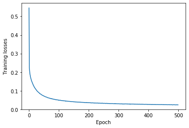

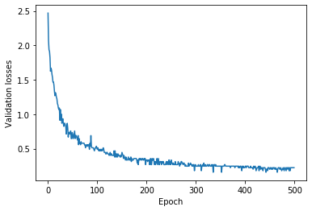

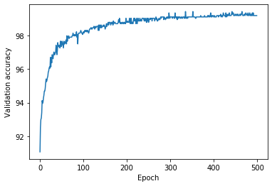

```python
D_in = 11 # Number of features that will feed our system
D_out= 1 # Number of "things" that will be predicted, in our case only the quality of the wine

# When we create the model, its parameters are initialized.


model=nn.Sequential(nn.Linear(D_in,D_out),

                    nn.Sigmoid()
                   )

optimizer=th.optim.Adam(model.parameters(),lr=0.001)  # Chosen optimizer
loss_fn=nn.BCELoss()                                  # Adequate loss function Binary Cross-Entropy
epochs=500
batch_size=20   # Number of samples that we treat before update the gradient such as in descent gradient, a trade-off between batch and gradient descent methods
train(model,optimizer,loss_fn,epochs,batch_size,x_train,y_train,x_test,y_test)
```

Firstly, it is very important to state that characteristics of the model such as the number of epochs, the batch size and the learning rate can be chosen arbitrarly by the user. We could have tested various combinations of these values that could improve or decrease the algorithm performance by decreasing overfitting phenomena and avoiding local minimas, but for shortening reason and for educational purposes, we just showed how our algorithm works for a specific value of this parameters, as seen before, we chose:

- Epochs = 500
- Batch size = 20
- Learning Rate = 0.001

As we can see from the first $\textbf{Graphic of Training Losses}$, the tendency of this kind of loss is always to decrease because we are learning from these own values and predictions. However, the fact that our training losses keep decreasing is not always a good sign. For example, if the number of epochs is very elevated, what can happens is that we may find a problem called overfitting, where our modelled over-learned from the training data.

About the $\textbf{Graphic of Validation Losses}$, it is normally the graphic where we can observe overfitting processes. When we have this phenomena, the validation losses stop of decreasing and begin to increase again for a given high epoch number. In our specific case we cannot see this phenomena. Nonetheless, around 200/300 epochs we can see that the validation losses do not decrease as it was doing before; it may be an indicative that we can stop around this number of epochs to avoid unnecessary computational calculations. It is common that programmers define a dropline based on the validation losses to avoid overfitting.

The $\textbf{Accuracy Graphic}$ shows us how accurate our trained algorithm is when applied to the testing dataset, it means, testing our model with data that our model never saw before and evaluate how it performs by predicting a result that is known beforehand (supervisioned learning).

Our algorithm got the best accuracy of $\textbf{99.436%}$ at the $\textbf{epoch 335 / 500}$. We are able to see the powerfullness of Machine Learning/Deep Learning networks. Using a very simple model with ONLY a logistic regression function we were able to get a very high accuracy of almost 100%, even though we used ALL the features and realized a very simple pre-treatment of the dataset. We know very well that not necessarily the 11 features are correlated with the type of wine, we could had performed a regression and PCA beforehand. For more complicated datasets this pre-treatement of the data MUST be realized and normally is essential around machine learning and deep learning models